# TP I FSBM UE 12: Big Data and predictive models

Introduction to machine learning.

Loic Verlingue, Md, PhDc loic.verlingue@gustaveroussy.fr

Yoann Pradat, PhDc yoann.pradat@centralesupelec.fr

20 January, 2021

[figure not shown]

# 1. What you will do in this R Notebook

## 1.1 Introduction

With this notebook you will work on **real cancer genomic data** to address clinical questions. The problem can be summarized this way: your input is a huge amount of variables, such as DNA or RNA sequences for each patient, that you wish to use in order to provide the clinician with a simple information that he can use for his patients.

The main challenge is how to **reduce information so that it becomes understandable a for a human**. That is a central objective in many machine learning projects.

Extracting biomedical knowledge from high-dimensional molecular data is currently part of the main challenges of personalized medecine, so let’s hope you’ll enjoy this introductive notebook and that it can help you to address your current and/or future research challenges.

## 1.2 Main steps

In this notebook, you will be guided through TCGA data. We shall download only parts of the data in order to be able to run jobs within a reasonable amount of time. To achieve this we will try to make the most of prior biomedical research and reduce our queries to most relevant genes.

In a first step we will implement simple modelling strategies to perform a classification task from expression data. In a second step, if there is enough for it, we will try to run a survival analysis so as to give you a general idea of the challenges of such analyses.

It is where the current science stands! To go further you’ll have to become a researcher in bioinformatics and machine learning.

## 1.3 In practice

The code is provided to you. You will just have to follow the instructions all along the notebook. Explanations and corrections will be given throughout the notebook for a subset of the questions.

**IMPORTANT** There are questions in this notebook that you need to answer and code that you need to write by yourself during the lab or at home. The ones you have to do during the lab are be indicated by a tag “INCLASS WORK”, and the ones you have to after the class are indicated by “HOME WORK”.

You will have to **complete both** and send the completed notebooks back to us. These completed notebooks will be used for evaluating your work in this module and give you a mark.

# 2 Get familiar with R notebooks

## 2.1 What is an R notebook

An *R notebook* is an R Markdown document (*.Rmd*) with text parts and R code parts (called *chunks*) that can be executed independently and interactively. R notebooks can be rendered (or knit) into different formats (*.pdf*, *.html*, *.docx*) using a renderer. The `rmarkdown` R package ([see doc here](https://cran.r-project.org/web/packages/rmarkdown/rmarkdown.pdf)) provides a lot of functions to render a notebook.

Running `render('TP_MachineLearning.Rmd', html_document())` from the R console will create a file *TP_MachineLearning.html* that you can then open with your favorite web browser.

`RStudio` already provides you with commands to render your R notebook by taking into accounts the headers that are specified at the top of document. You can knit your notebook with the `Preview` button or by pressing `Ctrl+Shift+K` (OS X: `Cmd+Shift+K`).

Here is an example of YAML headers for specifying the output format.

```yaml
title: Nineteen Years Later
author: Harry Potter
date: July 31, 2016
output:
  rmarkdown::html_document:
    theme: lumen
```

## 2.2 Execute code your first **chunk**

Try executing the following chunk by clicking the `Run` button within the chunk or by placing your cursor inside it and pressing `Ctrl+Enter` from within `R Studio`.

```r
print("Welcome to 'Big Data et predictive models' lab session")
```

```
## [1] "Welcome to 'Big Data et predictive models' lab session"
```

In order to create a new chunk, open it with “```{r}” and close it with “```”. Alternatively, press `Ctrl + Alt + I` (OS X:`Cmd + Option + I`) or the Add Chunk button in the tool bar of `R Studio`. Chunks rendering can by customized by specifying chunk options among the following

- `include = FALSE` prevents code and results from appearing in the finished file. R Markdown still runs the code in the chunk, and the results can be used by other chunks.
- `echo = FALSE` prevents code, but not the results from appearing in the finished file. This is a useful way to embed figures.
- `message = FALSE` prevents messages that are generated by code from appearing in the finished file.
- `warning = FALSE` prevents warnings that are generated by code from appearing in the finished.
- `fig.cap = "..."` adds a caption to graphical results.
- `fig.width = 4` width of the graphical results
- `fig.height = 3` height of the graphical results
- `fig.align = center` height of the graphical results
- `dev = "png"` the graphical device to generate plots
- …

Options can also be set from within the chunk using the syntax `knitr::opts_chunk$set(fig.width = 6, fig.height = 6)` for instance. For more details about chunk options, see the online documentation https://yihui.org/knitr/options/.

*Pratical info*: A list of all the keyboard shortcuts for `Rstudio` is available [here](https://support.rstudio.com/hc/en-us/articles/200711853-Keyboard-Shortcuts).

**INCLASS WORK**: Create an `R` chunk that displays a plot of the cosinus and sinus functions on $[-\pi, \pi]$ withouth showing the code, with a caption, with a width and height of 8 and 4 respectively. The plot should additionally be centered.

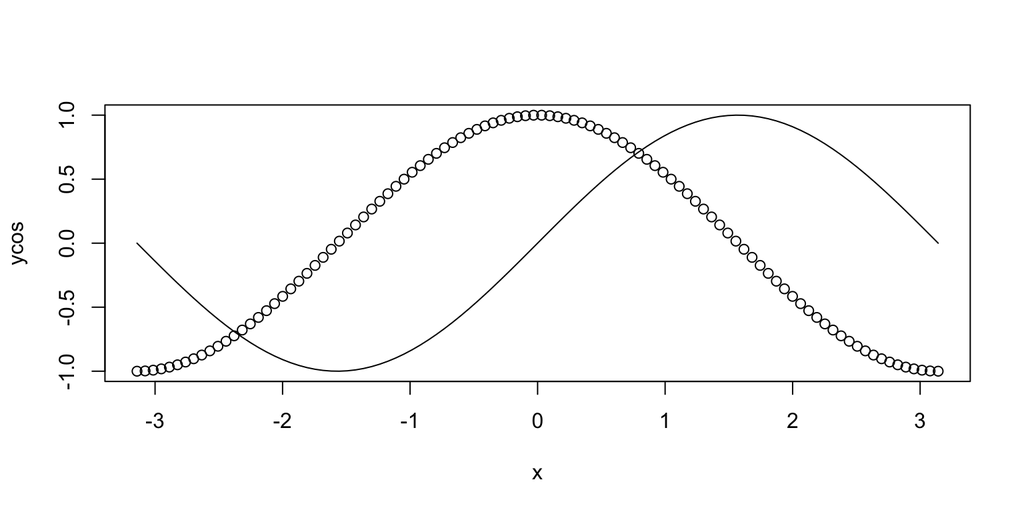

Cosinus and sinus plot

# 3. Classification using expression data.